**Piotr Duszak - praca domowa 6 - sprawdzanie metryk uczciwości (ang. *fairness*) na przykładzie predykcji przychodów**

W niniejszym notebooku będą testowane modele, na to czy nie dyskryminują jednej z płci na podstawie danych o zarobkach. Na wejściu modelu są takie informacje jak wiek, ukończona edukacja, stan cywilny, zawód, liczba przepracowanych godzin tygodniowo, płeć, a na wyjściu to czy dana osoba zarabia rocznie więcej, czy mniej niż 50 000$

Zostały naczuone 4 modele (3 x modele drzewiaste) oraz sieć neuronowa.

# Część właściwa

## 2. Obliczenie metryk uczciwości (fairness)

Dla pierwszego modelu (którym jest las losowy) obliczono pięć metryk:

- statistical parity (SP) - określająca, czy etykieta wyjściowa równa 1 (oznaczająca zarabianie więcej niż 50 000) występuje tyle samo razy dla obydwu płci
- equal oportunity (EO) - określająca, czy model posiada taki samą czułość (true positive rate) dla obydwu płci
- predictive parity (PP) - określająca, czy model posiada taki samą samą pozytywną wartość predykcyjną (posotive predictive value) dla obydwu płci
- predictive equality (PE) - określająca, czy model ma taki sam współczynnik wyników fałszywie dodatnich (false positive rate) dla obydwu płci
- accuracy equality (AE) - określająca, czy model ma taką sama trafność (accuracy) dla obydwu płci

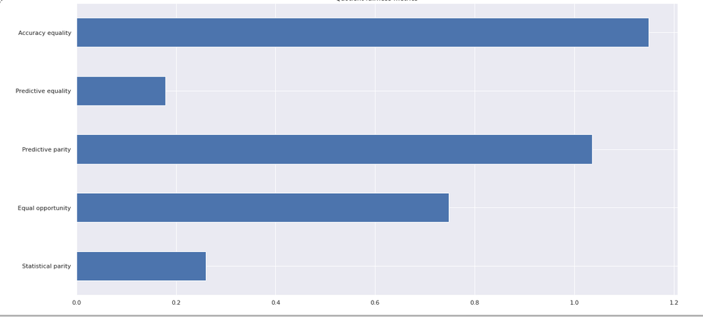

Jak widać dwie z pięciu metryk (AE oraz PP) mieszczą się w granicach dopuszczalności, ale pozostałe zdecydowanie nie. W szczególości metryka SP jest bardzo niska co oznacza, że szanse mężczyzn na uzyskanie według modelu płacy powyżej 50 000$ rocznie jest znacznie większa niż dla kobiet.

Postanowiono sprawdzić, czy w rzeczywistości istnieje zależność między płcią, a tym ile dana osoba zarabia. I niestety (ale nie zaskakująco) okazało się, że istnieje bardzo duża zależność.

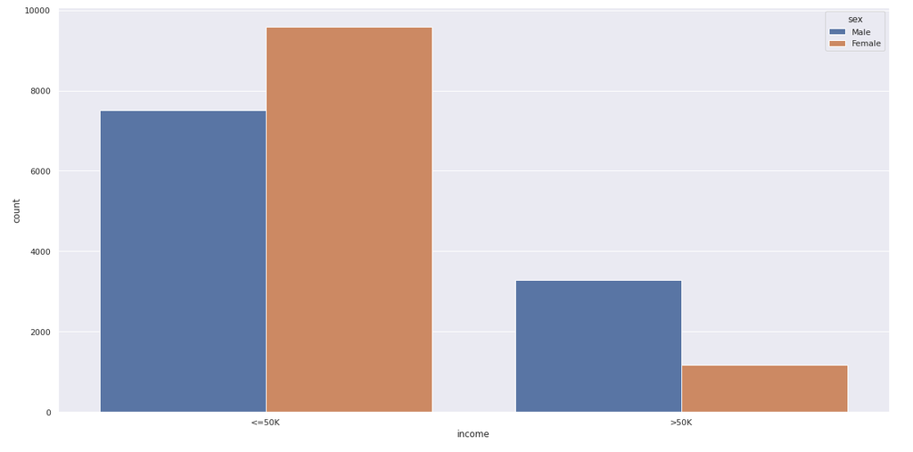

**Komentarz:**

Niestety pierwszy model okazał się bardzo dyskryminujący kobiety. Na pięć sprawdzonych metryk, tylko dwie mieściły się w dopuszczalnych granicach, a pozostałe trzy były bardzo dalekie od tego. Aczkolwiek nie jest dziwne, że model okazał się dyskryminujący skoro, rzeczywiste dane takie są.

## 3. Wytrenowanie trzech innych modeli i obliczenie metryk uczciwości

Postanowiono skontruować następnujęce modele:

- sieć neuronową
- model typu gradient boost
- zmodyfikowany model lasu losowego w taki sposób, że przed ostateczną predykcją sztucznie zwiększamy szanse kobiet, a zmniejszamy mężczyzn

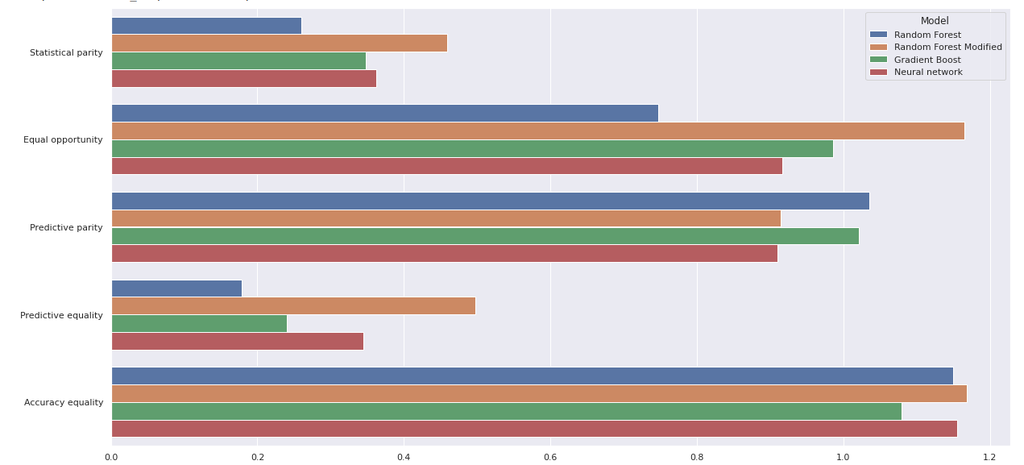

**Komentarz:**

Wszystkie modele mają bardzo podobne accuracy (na poziomie 85%). Jak widać nie udało się uzyskać modelu, który spełniałby wszystkie metryki. Trzy na cztery modele posiadają trzy metryki w dopuszczalnych granicach. Żaden model nie posiada dopuszczalnych wartości dla metryki SP oraz PE.

Najlepszy pod tym względem okazał się ręcznie poprawiany losowy las. Po pierwsze metryki EO, PP oraz AE są w dopuszczalnych granicach, a po drugie pozostałe metryki są najbliżej jedynki.

# Załącznik

## Wczytanie danych

Dane zostały wczytane, a następnie zmodyfikowane w taki sposób, żeby liczba osób płci żeńskiej oraz męskiej była taka sama.

```python
import pandas as pd
import seaborn as sns

df = pd.read_csv('adult.csv')
df = df.dropna().replace('?', 'Unknown').drop(['fnlwgt', 'capital.gain', 'capital.loss'], axis=1)
df = pd.concat([df[df['sex']=='Male'].sample(frac=0.495, random_state=0), df[df['sex']=='Female']])
df = df.sample(frac=1, random_state=0).reset_index(drop=True)
df
```

|  | age | workclass | education | education.num | marital.status | occupation | relationship | race | sex | hours.per.week | native.country | income |
| --- | --- | --- | --- | --- | --- | --- | --- | --- | --- | --- | --- | --- |
| 0 | 41 | Self-emp-not-inc | HS-grad | 9 | Married-civ-spouse | Other-service | Husband | White | Male | 10 | United-States | <=50K |
| 1 | 44 | State-gov | Some-college | 10 | Married-civ-spouse | Exec-managerial | Husband | White | Male | 40 | United-States | <=50K |
| 2 | 21 | Private | HS-grad | 9 | Never-married | Machine-op-inspct | Not-in-family | White | Female | 40 | United-States | <=50K |
| 3 | 19 | Private | HS-grad | 9 | Married-AF-spouse | Adm-clerical | Wife | White | Female | 25 | United-States | <=50K |
| 4 | 38 | Private | HS-grad | 9 | Married-civ-spouse | Machine-op-inspct | Husband | White | Male | 48 | United-States | >50K |
| ... | ... | ... | ... | ... | ... | ... | ... | ... | ... | ... | ... | ... |
| 21552 | 50 | Private | Assoc-acdm | 12 | Married-civ-spouse | Exec-managerial | Wife | Black | Female | 40 | United-States | >50K |
| 21553 | 37 | Private | 5th-6th | 3 | Separated | Other-service | Unmarried | White | Female | 40 | Mexico | <=50K |
| 21554 | 52 | Self-emp-not-inc | HS-grad | 9 | Divorced | Craft-repair | Not-in-family | Black | Male | 40 | United-States | <=50K |
| 21555 | 63 | Federal-gov | Doctorate | 16 | Divorced | Exec-managerial | Not-in-family | White | Female | 60 | United-States | >50K |
| 21556 | 42 | Private | Doctorate | 16 | Never-married | Prof-specialty | Not-in-family | White | Male | 50 | United-States | <=50K |

21557 rows × 12 columns

Dane składają się z następujących kolumn:

- age = wiek
- workclass = obszar pracy (prywatny, rządowy, samozatrudnienie, itp.)
- education = rodzaj ukończonej edukacji
- education.num = liczba lat, które się uczyło
- maritial.status = stan cywilny
- occupation = zawód
- relationship = związki rodzinne
- race = rasa
- sex = płeć
- hours.per.week = liczba godzin tygodniowo
- nativ.country = kraj pochodzenia
- income = roczne przychody

Kolumny kategoryczne zostały zakodowane jako one-hot-encoding

```python
data = pd.get_dummies(df).drop(['income_<=50K', 'sex_Female'], axis=1)
columns_t = list(data.columns)[:-1]
data
```

|  | age | education.num | hours.per.week | workclass_Federal-gov | workclass_Local-gov | workclass_Never-worked | workclass_Private | workclass_Self-emp-inc | workclass_Self-emp-not-inc | workclass_State-gov | workclass_Unknown | workclass_Without-pay | education_10th | education_11th | education_12th | education_1st-4th | education_5th-6th | education_7th-8th | education_9th | education_Assoc-acdm | education_Assoc-voc | education_Bachelors | education_Doctorate | education_HS-grad | education_Masters | education_Preschool | education_Prof-school | education_Some-college | marital.status_Divorced | … |
| --- | --- | --- | --- | --- | --- | --- | --- | --- | --- | --- | --- | --- | --- | --- | --- | --- | --- | --- | --- | --- | --- | --- | --- | --- | --- | --- | --- | --- | --- | --- |
| 0 | 41 | 9 | 10 | 0 | 0 | 0 | 0 | 0 | 1 | 0 | 0 | 0 | 0 | 0 | 0 | 0 | 0 | 0 | 0 | 0 | 0 | 0 | 0 | 1 | 0 | 0 | 0 | 0 | 0 | … |
| 1 | 44 | 10 | 40 | 0 | 0 | 0 | 0 | 0 | 0 | 1 | 0 | 0 | 0 | 0 | 0 | 0 | 0 | 0 | 0 | 0 | 0 | 0 | 0 | 0 | 0 | 0 | 0 | 1 | 0 | … |
| 2 | 21 | 9 | 40 | 0 | 0 | 0 | 1 | 0 | 0 | 0 | 0 | 0 | 0 | 0 | 0 | 0 | 0 | 0 | 0 | 0 | 0 | 0 | 0 | 1 | 0 | 0 | 0 | 0 | 0 | … |
| 3 | 19 | 9 | 25 | 0 | 0 | 0 | 1 | 0 | 0 | 0 | 0 | 0 | 0 | 0 | 0 | 0 | 0 | 0 | 0 | 0 | 0 | 0 | 0 | 1 | 0 | 0 | 0 | 0 | 0 | … |
| 4 | 38 | 9 | 48 | 0 | 0 | 0 | 1 | 0 | 0 | 0 | 0 | 0 | 0 | 0 | 0 | 0 | 0 | 0 | 0 | 0 | 0 | 0 | 0 | 1 | 0 | 0 | 0 | 0 | 0 | … |
| ... | ... | ... | ... | ... | ... | ... | ... | ... | ... | ... | ... | ... | ... | ... | ... | ... | ... | ... | ... | ... | ... | ... | ... | ... | ... | ... | ... | ... | ... | … |
| 21552 | 50 | 12 | 40 | 0 | 0 | 0 | 1 | 0 | 0 | 0 | 0 | 0 | 0 | 0 | 0 | 0 | 0 | 0 | 0 | 1 | 0 | 0 | 0 | 0 | 0 | 0 | 0 | 0 | 0 | … |
| 21553 | 37 | 3 | 40 | 0 | 0 | 0 | 1 | 0 | 0 | 0 | 0 | 0 | 0 | 0 | 0 | 0 | 1 | 0 | 0 | 0 | 0 | 0 | 0 | 0 | 0 | 0 | 0 | 0 | 0 | … |
| 21554 | 52 | 9 | 40 | 0 | 0 | 0 | 0 | 0 | 1 | 0 | 0 | 0 | 0 | 0 | 0 | 0 | 0 | 0 | 0 | 0 | 0 | 0 | 0 | 1 | 0 | 0 | 0 | 0 | 1 | … |
| 21555 | 63 | 16 | 60 | 1 | 0 | 0 | 0 | 0 | 0 | 0 | 0 | 0 | 0 | 0 | 0 | 0 | 0 | 0 | 0 | 0 | 0 | 0 | 1 | 0 | 0 | 0 | 0 | 0 | 1 | … |
| 21556 | 42 | 16 | 50 | 0 | 0 | 0 | 1 | 0 | 0 | 0 | 0 | 0 | 0 | 0 | 0 | 0 | 0 | 0 | 0 | 0 | 0 | 0 | 1 | 0 | 0 | 0 | 0 | 0 | 0 | … |

21557 rows × 105 columns

## 1. Nauczenie modelu drzewiastego (RFC)

Najpierw został nauczony model typu las losowy o maksymalnej głębokości 10 oraz składający się z 20 drzew.

```python
from sklearn.ensemble import RandomForestClassifier

X = data[columns_t]
y = data[['income_>50K']]
thresh = int(21557*0.7)
train_x, test_x = X.loc[:thresh], X.loc[thresh:]
train_y, test_y = y.loc[:thresh], y.loc[thresh:]
rfc = RandomForestClassifier(max_depth=10, n_estimators=20, random_state=0)
rfc.fit(train_x, train_y['income_>50K'])
print('Accuracy na zbiorze testowym', rfc.score(test_x, test_y))
y_hat = pd.DataFrame(rfc.predict(X), columns=['income_>50K'])
```

```
Accuracy na zbiorze testowym 0.8540507111935683
```

Osiągnął on trafność na zbiorze testowym 85.4%

## 2. Obliczenie metryk uczciwości (fairness)

```python
# Funkcje obliczające kolejne metryki uczciwości oraz funkcja agregująca je wszystkie dla danego modelu

def stat_par(y_hat, prot_Female, prot_Male):
  fem_data = (y_hat[prot_Female]==1).mean()
  mal_data = (y_hat[prot_Male]==1).mean()
  return pd.concat([fem_data, mal_data], axis=1).rename(columns={0: 'Female', 1: 'Male'}, index={'income_>50K': 'Statistical parity'})

def equal_opo(y_hat, y, prot_Female, prot_Male):
  y_1 = (y['income_>50K']==1)
  fem_data = (y_hat[prot_Female & y_1]==1).mean()
  mal_data = (y_hat[prot_Male & y_1]==1).mean()
  return pd.concat([fem_data, mal_data], axis=1).rename(columns={0: 'Female', 1: 'Male'}, index={'income_>50K': 'Equal opportunity'})

def pred_par(y_hat, y, prot_Female, prot_Male):
  y_hat_1 = (y_hat['income_>50K']==1)
  fem_data = (y[prot_Female & y_hat_1]==1).mean()
  mal_data = (y[prot_Male & y_hat_1]==1).mean()
  return pd.concat([fem_data, mal_data], axis=1).rename(columns={0: 'Female', 1: 'Male'}, index={'income_>50K': 'Predictive parity'})

def pred_equ(y_hat, y, prot_Female, prot_Male):
  y_0 = (y['income_>50K']==0)
  fem_data = (y_hat[prot_Female & y_0]==1).mean()
  mal_data = (y_hat[prot_Male & y_0]==1).mean()
  return pd.concat([fem_data, mal_data], axis=1).rename(columns={0: 'Female', 1: 'Male'}, index={'income_>50K': 'Predictive equality'})

def acc_equ(y_hat, y, prot_Female, prot_Male):
  fem_data = (y_hat[prot_Female]==y[prot_Female]).mean()
  mal_data = (y_hat[prot_Male]==y[prot_Male]).mean()
  return pd.concat([fem_data, mal_data], axis=1).rename(columns={0: 'Female', 1: 'Male'}, index={'income_>50K': 'Accuracy equality'})

def agreg_all_metrics(y_hat, y, prot_Female, prot_Male):
  fairness_data = []
  fairness_data.append(stat_par(y_hat, data_Female, data_Male))
  fairness_data.append(equal_opo(y_hat, y, data_Female, data_Male))
  fairness_data.append(pred_par(y_hat, y, data_Female, data_Male))
  fairness_data.append(pred_equ(y_hat, y, data_Female, data_Male))
  fairness_data.append(acc_equ(y_hat, y, data_Female, data_Male))
  fairness_data = pd.concat(fairness_data)
  fairness_data['Quotient'] = fairness_data['Female']/fairness_data['Male']
  return fairness_data
```

Dla pierwszego modelu obliczono pięć metryk:

- statistical parity (SP) - określająca, czy etykieta wyjściowa równa 1 (oznaczająca zarabianie więcej niż 50 000) występuje tyle samo razy dla obydwu płci
- equal oportunity (EO) - określająca, czy model posiada taki samą czułość (true positive rate) dla obydwu płci
- predictive parity (PP) - określająca, czy model posiada taki samą samą pozytywną wartość predykcyjną (posotive predictive value) dla obydwu płci
- predictive equality (PE) - określająca, czy model ma taki sam współczynnik wyników fałszywie dodatnich (false positive rate) dla obydwu płci
- accuracy equality (AE) - określająca, czy model ma taką sama trafność (accuracy) dla obydwu płci

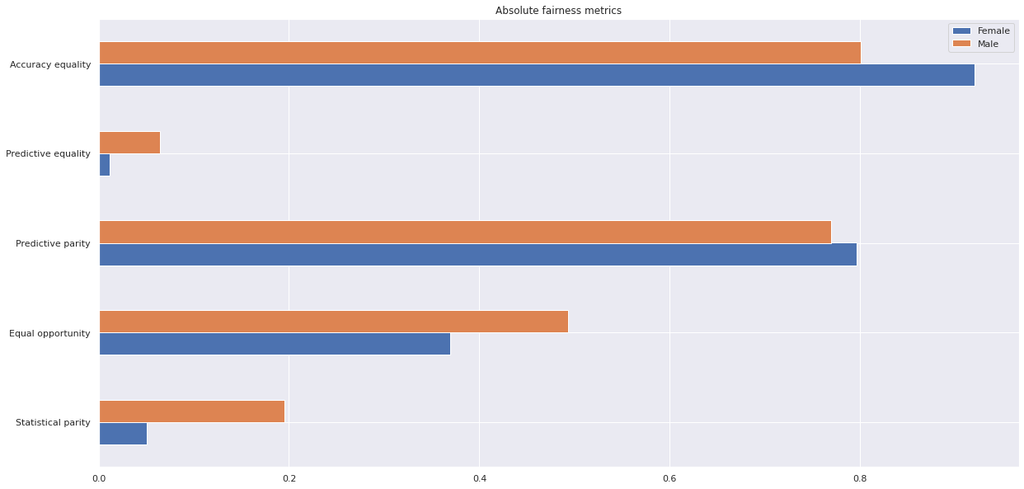

```python
data_Female = (X['sex_Male']==0)
data_Male = (X['sex_Male']==1)
fd1 = agreg_all_metrics(y_hat, y, data_Female, data_Male)
sns.set(rc={'figure.figsize':(20, 10)})
ax1 = fd1[['Female', 'Male']].plot.barh()
fd1['Model'] = 'Random Forest'
ax1.set_title('Absolute fairness metrics');
```

Powyżej widać wspominane metryki obliczone dla obydwu płci. Aczkolwiek na takim wykresie ciężko oceniać, czy dana metryka jest wystarczająco podobna dla obydwu grup w związku z tym obliczono iloraz każdej metryki dla płci żeńskiej w stosunku do męskiej.

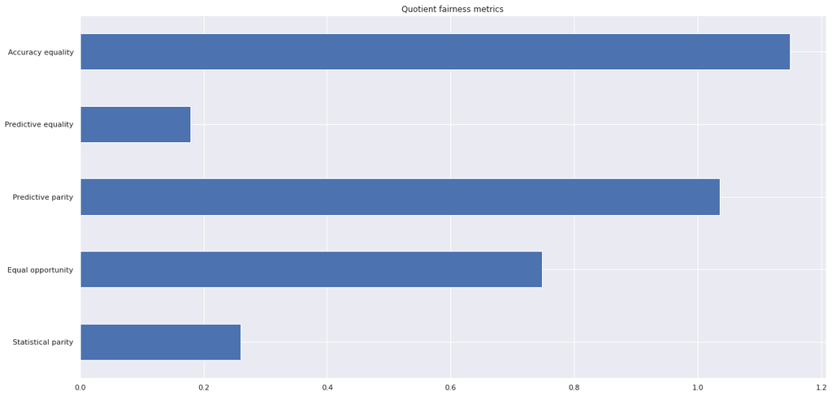

```python
ax2 = fd1['Quotient'].plot.barh()
ax2.set_title('Quotient fairness metrics');
```

Jak widać dwie z pięciu metryk (AE oraz PP) mieszczą się w granicach dopuszczalności, ale pozostałe zdecydowanie nie. W szczególości metryka SP jest bardzo niska co oznacza, że szanse mężczyzn na uzyskanie według modelu płacy powyżej 50 000$ rocznie jest znacznie większa niż dla kobiet.

Postanowiono sprawdzić, czy w rzeczywistości istnieje zależność między płcią, a tym ile dana osoba zarabia. I niestety (ale nie zaskakująco) okazało się, że istnieje bardzo duża zależność.

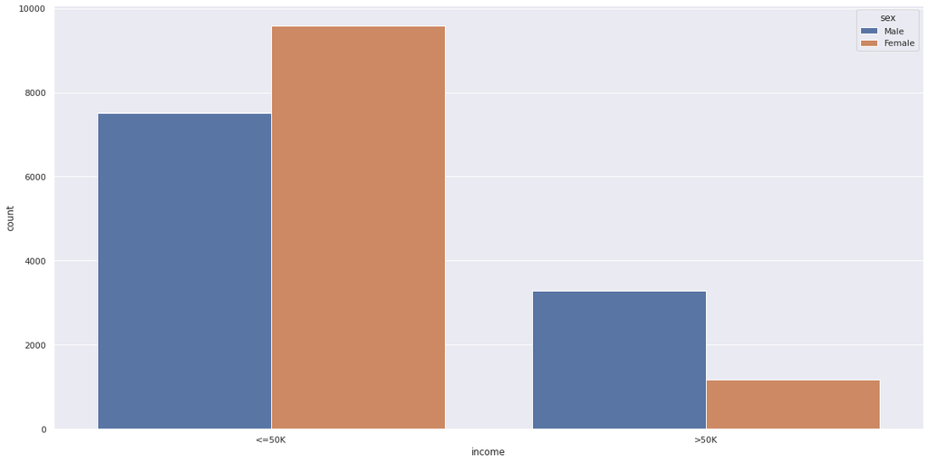

```python
sns.countplot(x='income', data=df, hue='sex');
```

**Komentarz:**

Niestety pierwszy model okazał się bardzo dyskryminujący kobiety. Na pięć sprawdzonych metryk, tylko dwie mieściły się w dopuszczalnych granicach, a pozostałe trzy były bardzo dalekie od tego. Aczkolwiek nie jest dziwne, że model okazał się dyskryminujący skoro, rzeczywiste dane takie są.

## 3. Wytrenowanie trzech innych modeli i obliczenie metryk uczciwości

Postanowiono skontruować następnujęce model:

- sieć neuronową
- model typu gradient boost
- zmodyfikowany model lasu losowego w taki sposób, że przed ostateczną predykcją sztucznie zwiększamy szanse kobiet, a zmniejszamy mężczyzn

```python
def rfc_modif_pred(rfc, X):
  y_tmp = rfc.predict_proba(X)
  y_tmp[data_Male] += [0.08, -0.08]
  y_tmp[data_Female] += [-0.08, 0.08]
  return y_tmp.argmax(axis=1)

y_hat = pd.DataFrame(rfc_modif_pred(rfc, X), columns=['income_>50K'])
fd2 = agreg_all_metrics(y_hat, y, data_Female, data_Male)
fd2['Model'] = 'Random Forest Modified'
print('Accuracy na zbiorze testowym dla zmodyfikowanego lasu losowego ', (y_hat==y).mean()[0])
```

```
Accuracy na zbiorze testowym dla zmodyfikowanego lasu losowego  0.8576332513800622
```

Zmodyfikowany las losowy uzyskał bardzo podobną trafność co pierwotny

```python
from sklearn.ensemble import GradientBoostingClassifier

gbc = GradientBoostingClassifier(max_depth=10, random_state=0)
gbc.fit(train_x, train_y['income_>50K'])
print('Accuracy na zbiorze testowym dla Gradient Boosta', gbc.score(test_x, test_y))
y_hat = pd.DataFrame(gbc.predict(X), columns=['income_>50K'])
fd3 = agreg_all_metrics(y_hat, y, data_Female, data_Male)
fd3['Model'] = 'Gradient Boost'
```

```
Accuracy na zbiorze testowym dla Gradient Boosta 0.8491032776747063
```

```python
from tensorflow.keras import Sequential
from tensorflow.keras.layers import *
from tensorflow.keras.optimizers import *

nn = Sequential()
nn.add(BatchNormalization(input_shape=(104,)))
nn.add(Dense(64, activation='relu'))
nn.add(Dropout(0.5))
nn.add(Dense(128, activation='relu'))
nn.add(Dropout(0.5))
nn.add(Dense(64, activation='relu'))
nn.add(Dropout(0.5))
nn.add(Dense(1, activation='sigmoid'))

# Uczenie sieci
nn.compile(optimizer=SGD(0.01), loss='binary_crossentropy', metrics='acc')
nn.fit(train_x.astype(float), train_y.astype(float), batch_size=8, epochs=5, validation_data=(test_x.astype(float), test_y.astype(float)))
```

```
<tensorflow.python.keras.callbacks.History at 0x7f13000aead0>
```

```python
y_hat = pd.DataFrame((nn.predict(X)>0.5).astype(int), columns=['income_>50K'])
fd4 = agreg_all_metrics(y_hat, y, data_Female, data_Male)
fd4['Model'] = 'Neural network'
fair_all = pd.concat([fd1, fd2, fd3, fd4])
```

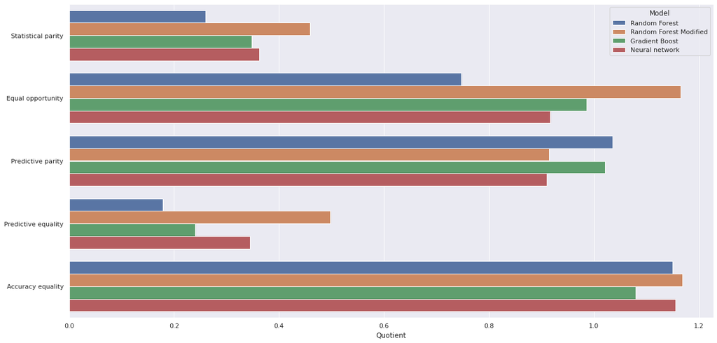

```python
graph_data = fair_all[['Quotient', 'Model']]
sns.barplot(y=graph_data.index, x='Quotient', hue='Model', data=graph_data)
```

**Komentarz:**

Wszystkie modele mają bardzo podobne accuracy (na poziomie 85%). Jak widać nie udało się uzyskać modelu, który spełniałby wszystkie metryki. Trzy na cztery modele posiadają trzy metryki w dopuszczalnych granicach. Żaden model nie posiada dopuszczalnych wartości dla metryki SP oraz PE.

Najlepszy pod tym względem okazał się ręcznie poprawiany losowy las. Po pierwsze metryki EO, PP oraz AE są w dopuszczalnych granicach, a po drugie pozostałe metryki są najbliżej jedynki.